# NLA HydrAP effects exploration

C. Emi Fergus

2024-02-22

Exploratory plots of lake physical, chemical, and biological characteristics related to potential hydro-alteration rankings (HydrAP). Combined NLA 2007, 2012, and 2017 data and grouped by 5-aggregated ecoregion.

## Table of HydrAP class and ecoregion

Potential hydro-alteration classes are grouped as HydrAP <3 = “Low”; HydrAP <= 5 = “Moderate”; HydrAP > 5 = “High”. Note: missing HydrAP ranks for n=275 sites where dam height could not be gathered but dams were observed by NLA field crew

| ECOP5_2015 | HydrAP class Low | HydrAP class Moderate | HydrAP class High | HydrAP class NA |
| --- | --- | --- | --- | --- |
| APPS | 215 | 184 | 194 | 58 |
| CENPL | 348 | 276 | 271 | 112 |
| CPL | 117 | 139 | 76 | 46 |
| UMW | 314 | 121 | 10 | 16 |
| WEST | 366 | 157 | 213 | 43 |

## Boxplots of Macroinvertebrate MMI by HydrAP rank

There are n = 335 observations missing MMI_BENT values.

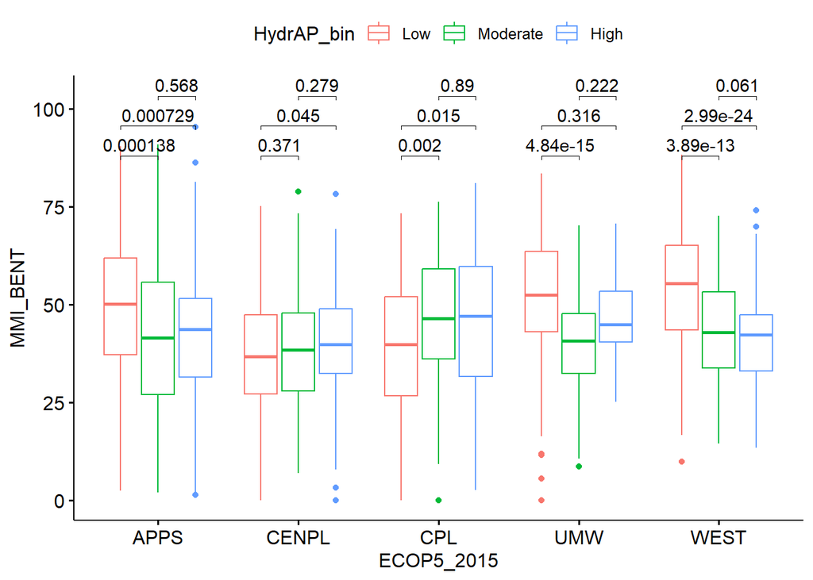

In the WEST and APPS, macroinvertebrate MMI decreased with greater hydro-alteration potential. In the UMW, macroinvert MMI was lower in Moderate HydrAP ranked lakes compared to Low ranks. In the CPL and CENPL, we see opposite relationships where macroinvert MMI values increase with greater hydro-alteration potential.

## Boxplots of zooplankton MMI by HydrAP

Zooplankton MMI were not calculated for NLA 2007.

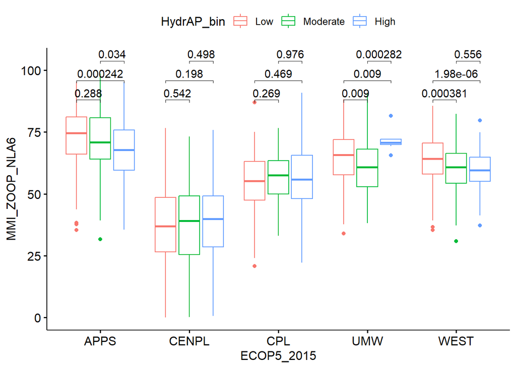

## TOTAL PHOSPHORUS and HydrAP

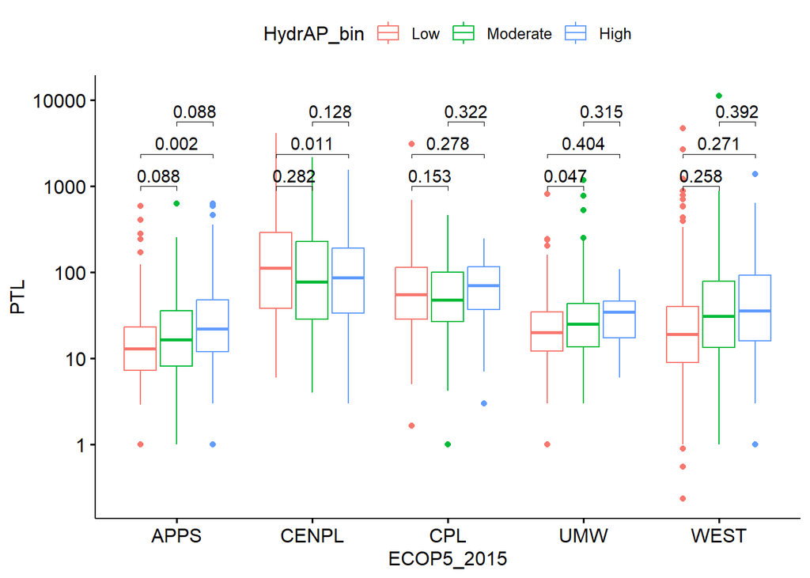

## TOTAL NITROGEN and HydrAP

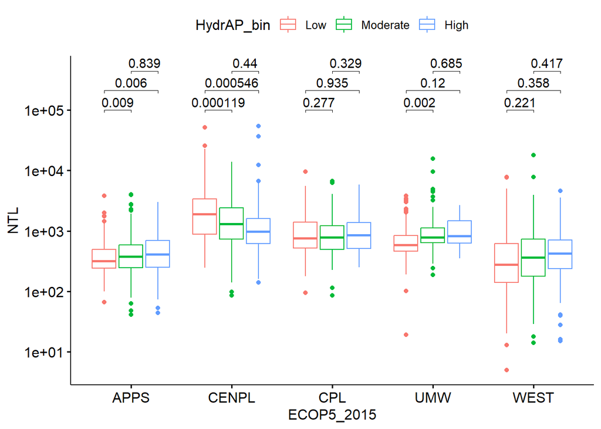

## CHLa and HydrAP

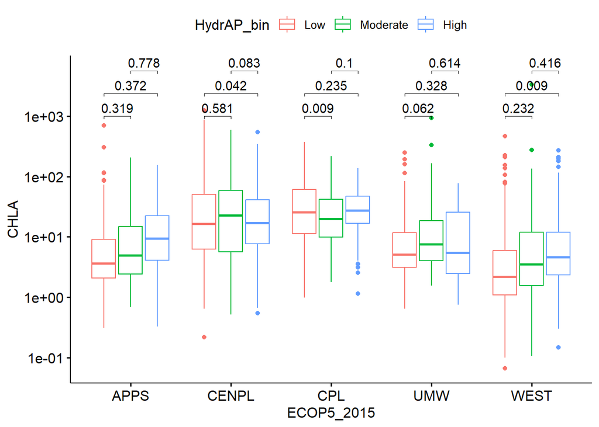

Chla concentrations do not show strong relationships with HydrAP ranks.

## Vertical DD and HydrAP

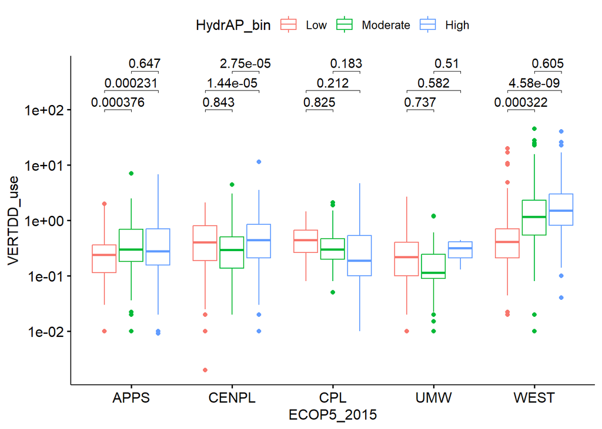

## Horizontal DD and HydrAP

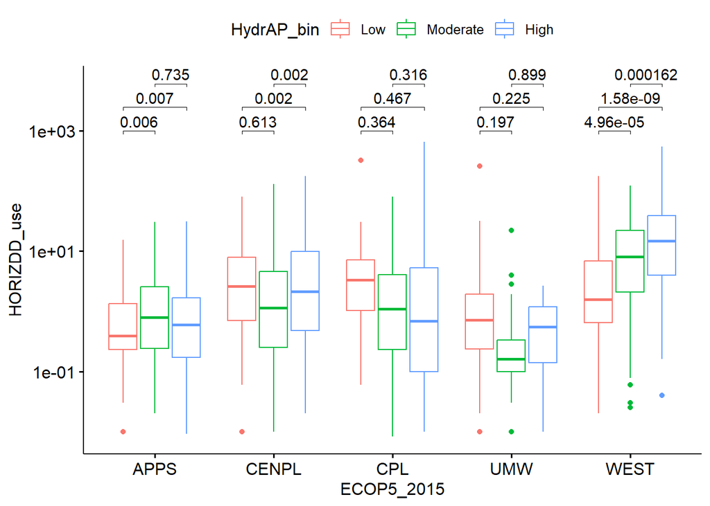

## E:I and HydrAP

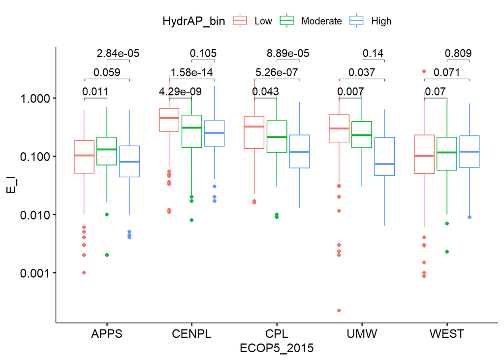

Evaporation-to-inflow ratio decreases with greater HydrAP rank within most ecoregions. Lakes with greater potential anthropogenic hydro-alteration tend to be more flow through systems.

# Path diagram of hypothesized altered hydro effects on lakes

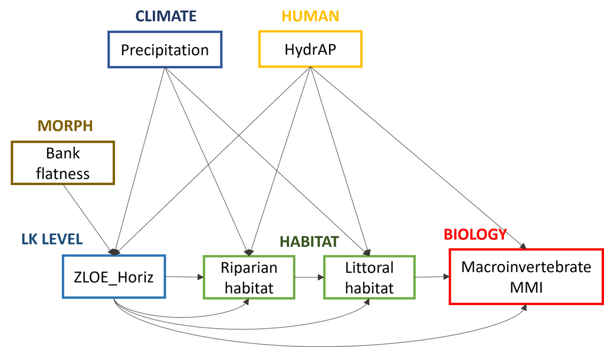

Created in powerpoint

# Structural equation model of hypothesized altered hydro effects on lakes with latent variables

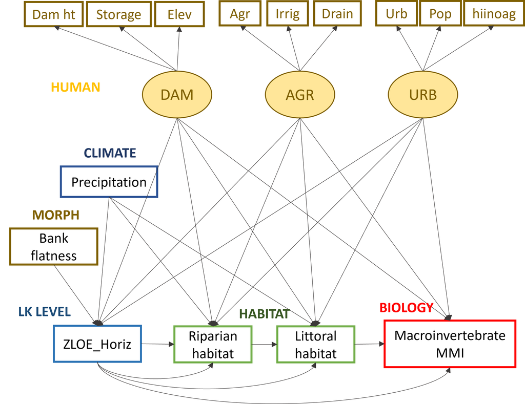

Created in powerpoint